# Homework 3

Author

Qi He

## GitHub repository: https://github.com/Qi-He1/stats506-hw3

```r
library(haven)
library(dplyr)
library(broom)
```

## **Problem 1**

**a.**

```r
aux <- read_xpt("AUX_I.xpt")
demo <- read_xpt("DEMO_I.xpt")

nhanes <- inner_join(aux, demo, by = "SEQN")

dim(nhanes)
```

```
[1] 4582  119
```

The merged data frame contains 4,582 observations and 119 variables.

**b.**

```r
table(nhanes$RIAGENDR, useNA = "ifany")
```

```
   1    2
2176 2406
```

```r
table(nhanes$DMDCITZN, useNA = "ifany")
```

```
   1    2    7    9 <NA>
3684  884    8    5    1
```

```r
table(nhanes$DMDHHSZA, useNA = "ifany")
```

```
   0    1    2    3
3463  737  317   65
```

```r
table(nhanes$INDHHIN2, useNA = "ifany")
```

```
   1    2    3    4    5    6    7    8    9   10   12   13   14   15   77   99
 101  146  233  262  272  461  439  381  295  244  145   53  458  795   86   63
<NA>
 148
```

```r
nhanes <- nhanes %>%
  mutate(
    gender = factor(
      RIAGENDR,
      levels = c(1, 2),
      labels = c("Male", "Female")
    ),

    citizenship = factor(
      DMDCITZN,
      levels = c(1, 2),
      labels = c("US citizen", "Not a US citizen")
    ),

    children_under5 = DMDHHSZA,

    income_group = factor(
      INDHHIN2,
      levels = c(1:10, 14, 15),
      labels = c(
        "$0-$4,999",
        "$5,000-$9,999",
        "$10,000-$14,999",
        "$15,000-$19,999",
        "$20,000-$24,999",
        "$25,000-$34,999",
        "$35,000-$44,999",
        "$45,000-$54,999",
        "$55,000-$64,999",
        "$65,000-$74,999",
        "$75,000-$99,999",
        "$100,000+"
      ),
      ordered = TRUE
    )
  )
```

```r
nhanes <- nhanes %>%
  mutate(income_score = as.numeric(income_group))
```

```r
table(nhanes$gender, useNA = "ifany")
```

```
  Male Female
  2176   2406
```

```r
table(nhanes$citizenship, useNA = "ifany")
```

```
      US citizen Not a US citizen             <NA>
            3684              884               14
```

```r
table(nhanes$children_under5, useNA = "ifany")
```

```
   0    1    2    3
3463  737  317   65
```

```r
table(nhanes$income_group, useNA = "ifany")
```

```
      $0-$4,999   $5,000-$9,999 $10,000-$14,999 $15,000-$19,999 $20,000-$24,999
            101             146             233             262             272
$25,000-$34,999 $35,000-$44,999 $45,000-$54,999 $55,000-$64,999 $65,000-$74,999
            461             439             381             295             244
$75,000-$99,999       $100,000+            <NA>
            458             795             495
```

```r
table(nhanes$income_score, useNA = "ifany")
```

```
   1    2    3    4    5    6    7    8    9   10   11   12 <NA>
 101  146  233  262  272  461  439  381  295  244  458  795  495
```

Gender was converted to a factor with informative labels for males and females. Citizenship status was converted to a factor with informative labels, and refused and unknown responses were treated as missing. The number of children aged five or younger was retained as a continuous variable. For household income, overlapping categories, refused responses, and unknown responses were treated as missing. The remaining income categories were reordered from 1 to 12 so that household income could be treated as a continuous covariate.

**c.**

```r
model_1R <- glm(
  AUXTWIDR ~ gender,
  data = nhanes,
  family = poisson
)

model_2R <- glm(
  AUXTWIDR ~ gender + citizenship + children_under5 + income_score,
  data = nhanes,
  family = poisson
)

model_1L <- glm(
  AUXTWIDL ~ gender,
  data = nhanes,
  family = poisson
)

model_2L <- glm(
  AUXTWIDL ~ gender + citizenship + children_under5 + income_score,
  data = nhanes,
  family = poisson
)
```

```r
irr_table <- bind_rows(
  tidy(model_1R, exponentiate = TRUE) %>%
    mutate(Model = "1R"),

  tidy(model_2R, exponentiate = TRUE) %>%
    mutate(Model = "2R"),

  tidy(model_1L, exponentiate = TRUE) %>%
    mutate(Model = "1L"),

  tidy(model_2L, exponentiate = TRUE) %>%
    mutate(Model = "2L")
) %>%
  select(Model, term, IRR = estimate)

knitr::kable(
  irr_table,
  digits = 3,
  col.names = c("Model", "Coefficient", "Estimated IRR"),
  row.names = FALSE
)
```

| Model | Coefficient | Estimated IRR |
| --- | --- | --- |
| 1R | (Intercept) | 84.317 |
| 1R | genderFemale | 1.009 |
| 2R | (Intercept) | 88.437 |
| 2R | genderFemale | 1.015 |
| 2R | citizenshipNot a US citizen | 1.047 |
| 2R | children_under5 | 0.994 |
| 2R | income_score | 0.992 |
| 1L | (Intercept) | 84.758 |
| 1L | genderFemale | 1.013 |
| 2L | (Intercept) | 88.821 |
| 2L | genderFemale | 1.019 |
| 2L | citizenshipNot a US citizen | 1.022 |
| 2L | children_under5 | 0.983 |
| 2L | income_score | 0.993 |

```r
models <- list(
  "1R" = model_1R,
  "2R" = model_2R,
  "1L" = model_1L,
  "2L" = model_2L
)
```

```r
model_stats <- data.frame(
  Model = names(models),

  Sample_size = unname(
    sapply(models, nobs)
  ),

  Pseudo_R2 = unname(
    sapply(models, function(model) {
      y <- model.response(model.frame(model))

      null_model <- glm(
        y ~ 1,
        family = poisson
      )

      1 - as.numeric(
        logLik(model) / logLik(null_model)
      )
    })
  ),

  AIC = unname(
    sapply(models, AIC)
  )
)

knitr::kable(
  model_stats,
  digits = 3,
  row.names = FALSE
)
```

| Model | Sample_size | Pseudo_R2 | AIC |
| --- | --- | --- | --- |
| 1R | 4149 | 0.000 | 96618.48 |
| 2R | 3705 | 0.004 | 84916.04 |
| 1L | 4103 | 0.000 | 98685.15 |
| 2L | 3665 | 0.003 | 86597.96 |

The estimated IRRs were generally close to 1, indicating that the associations between the predictors and tympanometric width were relatively small. In the adjusted models, after controlling for citizenship status, the number of young children, and household income, females had slightly higher predicted tympanometric width than males in both ears. Non-US citizens also had slightly higher predicted values than US citizens. The IRRs for the number of young children and household income were slightly below 1. The pseudo-$R^2$ values were close to zero, indicating that the models explained only a small proportion of the variation in tympanometric width.

**d.**

```r
p <- summary(model_2L)$coefficients[
  "genderFemale",
  "Pr(>|z|)"
]

gender_IRR_test <- data.frame(
  IRR = round(
    exp(coef(model_2L)["genderFemale"]),
    4
  ),
  p_value = format.pval(
    p,
    digits = 4,
    eps = 0.0001
  )
)

dplyr::as_tibble(gender_IRR_test)
```

```
# A tibble: 1 × 2
    IRR p_value
  <dbl> <chr>
1  1.02 < 1e-04
```

```r
gender_means <- emmeans::emmeans(
  model_2L,
  ~ gender
)

gender_predictions <- emmeans::regrid(
  gender_means,
  transform = "response"
)

gender_predictions
```

```
 gender rate    SE  df asymp.LCL asymp.UCL
 Male   84.8 0.252 Inf      84.3      85.3
 Female 86.3 0.249 Inf      85.9      86.8

Results are averaged over the levels of: citizenship
Confidence level used: 0.95
```

```r
prediction_test <- pairs(gender_predictions)

prediction_test
```

```
 contrast      estimate    SE  df z.ratio p.value
 Male - Female    -1.59 0.308 Inf  -5.161 <0.0001

Results are averaged over the levels of: citizenship
```

In model 2L, the female-to-male IRR was 1.0187 ($p < 0.0001$), indicating that females had an approximately 1.87% higher predicted left-ear tympanometric width after controlling for the other variables. The adjusted predicted values were 84.8 for males and 86.3 for females, with a male-minus-female difference of -1.59 ($p < 0.0001$). Thus, both tests provide evidence that females have a small but statistically significant higher predicted left-ear tympanometric width than males.

## **Problem 2 - Sakila**

**a.**

```r
library(DBI)
library(RSQLite)
library(microbenchmark)
```

```r
sakila <- dbConnect(
  SQLite(),
  "sakila_master.db"
)

dbListTables(sakila)
```

```
 [1] "actor"                  "address"                "category"
 [4] "city"                   "country"                "customer"
 [7] "customer_list"          "film"                   "film_actor"
[10] "film_category"          "film_list"              "film_text"
[13] "inventory"              "language"               "payment"
[16] "rental"                 "sales_by_film_category" "sales_by_store"
[19] "staff"                  "staff_list"             "store"
```

R:

```r
customer_data <- dbGetQuery(
  sakila,
  "
  SELECT store_id, active
  FROM customer
  "
)
```

```r
result_2a_R <- customer_data %>%
  group_by(store_id) %>%
  summarise(
    total_customers = n(),
    active_percent = 100 * mean(as.numeric(active))
  )

result_2a_R
```

```
# A tibble: 2 × 3
  store_id total_customers active_percent
     <int>           <int>          <dbl>
1        1             326           97.5
2        2             273           97.4
```

SQL:

```r
result_2a_SQL <- dbGetQuery(
  sakila,
  "
  SELECT
    store_id,
    COUNT(*) AS total_customers,
    100.0 * AVG(active) AS active_percent
  FROM customer
  GROUP BY store_id
  ORDER BY store_id
  "
)

result_2a_SQL
```

```
  store_id total_customers active_percent
1        1             326       97.54601
2        2             273       97.43590
```

```r
benchmark_2a <- microbenchmark(
  R_approach = {
    customer_temp <- dbGetQuery(
      sakila,
      "
      SELECT store_id, active
      FROM customer
      "
    )

    customer_temp %>%
      group_by(store_id) %>%
      summarise(
        total_customers = n(),
        active_percent = 100 * mean(as.numeric(active)),
        .groups = "drop"
      )
  },

  SQL_approach = {
    dbGetQuery(
      sakila,
      "
      SELECT
        store_id,
        COUNT(*) AS total_customers,
        100.0 * AVG(active) AS active_percent
      FROM customer
      GROUP BY store_id
      ORDER BY store_id
      "
    )
  },

  times = 100
)

benchmark_2a
```

```
Unit: microseconds
         expr    min      lq     mean  median      uq    max neval cld
   R_approach 3049.5 3624.05 3914.326 3781.45 3936.25 7603.7   100  a
 SQL_approach  539.4  602.75  659.023  639.90  669.05 1167.8   100   b
```

Both approaches produced the same results. Store 1 had 326 customers, of whom 97.55% were active, while Store 2 had 273 customers, of whom 97.44% were active. Based on the median execution times, the single SQL query was faster than the R approach.

**b.**

R:

```r
staff_data <- dbGetQuery(
  sakila,
  "SELECT staff_id, first_name, last_name, address_id FROM staff"
)

address_data <- dbGetQuery(
  sakila,
  "SELECT address_id, city_id FROM address"
)

city_data <- dbGetQuery(
  sakila,
  "SELECT city_id, country_id FROM city"
)

country_data <- dbGetQuery(
  sakila,
  "SELECT country_id, country FROM country"
)
```

```r
result_2b_R <- staff_data %>%
  left_join(address_data, by = "address_id") %>%
  left_join(city_data, by = "city_id") %>%
  left_join(country_data, by = "country_id") %>%
  select(staff_id, first_name, last_name, country)

result_2b_R
```

```
  staff_id first_name last_name   country
1        1       Mike   Hillyer    Canada
2        2        Jon  Stephens Australia
```

SQL:

```r
result_2b_SQL <- dbGetQuery(
  sakila,
  "
  SELECT
    s.staff_id,
    s.first_name,
    s.last_name,
    co.country
  FROM staff AS s
  INNER JOIN address AS a
    ON s.address_id = a.address_id
  INNER JOIN city AS ci
    ON a.city_id = ci.city_id
  INNER JOIN country AS co
    ON ci.country_id = co.country_id
  ORDER BY s.staff_id
  "
)

dplyr::as_tibble(result_2b_SQL)
```

```
# A tibble: 2 × 4
  staff_id first_name last_name country
     <int> <chr>      <chr>     <chr>
1        1 Mike       Hillyer   Canada
2        2 Jon        Stephens  Australia
```

```r
benchmark_2b <- microbenchmark(
  R_approach = {
    staff_data <- dbGetQuery(
      sakila,
      "SELECT staff_id, first_name, last_name, address_id FROM staff"
    )

    address_data <- dbGetQuery(
      sakila,
      "SELECT address_id, city_id FROM address"
    )

    city_data <- dbGetQuery(
      sakila,
      "SELECT city_id, country_id FROM city"
    )

    country_data <- dbGetQuery(
      sakila,
      "SELECT country_id, country FROM country"
    )

    staff_data %>%
      left_join(address_data, by = "address_id") %>%
      left_join(city_data, by = "city_id") %>%
      left_join(country_data, by = "country_id") %>%
      select(staff_id, first_name, last_name, country)
  },

  SQL_approach = {
    dbGetQuery(
      sakila,
      "
      SELECT
        s.staff_id,
        s.first_name,
        s.last_name,
        co.country
      FROM staff AS s
      INNER JOIN address AS a
        ON s.address_id = a.address_id
      INNER JOIN city AS ci
        ON a.city_id = ci.city_id
      INNER JOIN country AS co
        ON ci.country_id = co.country_id
      ORDER BY s.staff_id
      "
    )
  },

  times = 100
)

benchmark_2b
```

```
Unit: microseconds
         expr    min      lq     mean  median      uq     max neval cld
   R_approach 6350.1 6572.65 6843.771 6701.05 6915.90 11224.3   100  a
 SQL_approach  412.3  453.60  496.078  494.00  522.35   809.0   100   b
```

Both approaches produced the same results. Mike Hillyer was located in Canada, while Jon Stephens was located in Australia. Based on the median execution times, the single SQL query was faster than the R approach.

**c.**

R:

```r
payment_data <- dbGetQuery(
  sakila,
  "SELECT rental_id, amount FROM payment"
)

rental_data <- dbGetQuery(
  sakila,
  "SELECT rental_id, inventory_id FROM rental"
)

inventory_data <- dbGetQuery(
  sakila,
  "SELECT inventory_id, film_id FROM inventory"
)

film_data <- dbGetQuery(
  sakila,
  "SELECT film_id, title FROM film"
)
```

```r
max_amount <- max(payment_data$amount)

result_2c_R <- payment_data %>%
  filter(amount == max_amount) %>%
  inner_join(rental_data, by = "rental_id") %>%
  inner_join(inventory_data, by = "inventory_id") %>%
  inner_join(film_data, by = "film_id") %>%
  distinct(title) %>%
  arrange(title)

result_2c_R
```

```
                  title
1 FLINTSTONES HAPPINESS
2   MIDSUMMER GROUNDHOG
3           MINE TITANS
4       SCORPION APOLLO
5             SHOW LORD
6        STING PERSONAL
7           TIES HUNGER
8             TRAP GUYS
9      VIRTUAL SPOILERS
```

SQL:

```r
result_2c_SQL <- dbGetQuery(
  sakila,
  "
  SELECT DISTINCT
    f.title
  FROM payment AS p
  INNER JOIN rental AS r
    ON p.rental_id = r.rental_id
  INNER JOIN inventory AS i
    ON r.inventory_id = i.inventory_id
  INNER JOIN film AS f
    ON i.film_id = f.film_id
  WHERE p.amount = (
    SELECT MAX(amount)
    FROM payment
  )
  ORDER BY f.title
  "
)

dplyr::as_tibble(result_2c_SQL)
```

```
# A tibble: 9 × 1
  title
  <chr>
1 FLINTSTONES HAPPINESS
2 MIDSUMMER GROUNDHOG
3 MINE TITANS
4 SCORPION APOLLO
5 SHOW LORD
6 STING PERSONAL
7 TIES HUNGER
8 TRAP GUYS
9 VIRTUAL SPOILERS
```

```r
benchmark_2c <- microbenchmark(
  R_approach = {
    payment_data <- dbGetQuery(
      sakila,
      "SELECT rental_id, amount FROM payment"
    )

    rental_data <- dbGetQuery(
      sakila,
      "SELECT rental_id, inventory_id FROM rental"
    )

    inventory_data <- dbGetQuery(
      sakila,
      "SELECT inventory_id, film_id FROM inventory"
    )

    film_data <- dbGetQuery(
      sakila,
      "SELECT film_id, title FROM film"
    )

    max_amount <- max(payment_data$amount)

    payment_data %>%
      filter(amount == max_amount) %>%
      inner_join(rental_data, by = "rental_id") %>%
      inner_join(inventory_data, by = "inventory_id") %>%
      inner_join(film_data, by = "film_id") %>%
      distinct(title) %>%
      arrange(title)
  },

  SQL_approach = {
    dbGetQuery(
      sakila,
      "
      SELECT DISTINCT
        f.title
      FROM payment AS p
      INNER JOIN rental AS r
        ON p.rental_id = r.rental_id
      INNER JOIN inventory AS i
        ON r.inventory_id = i.inventory_id
      INNER JOIN film AS f
        ON i.film_id = f.film_id
      WHERE p.amount = (
        SELECT MAX(amount)
        FROM payment
      )
      ORDER BY f.title
      "
    )
  },

  times = 100
)

benchmark_2c
```

```
Unit: milliseconds
         expr     min       lq      mean   median       uq     max neval cld
   R_approach 21.5100 22.68545 24.661790 24.60020 25.80245 31.8774   100  a
 SQL_approach  1.7107  1.89455  3.840271  5.23125  5.46835 11.2140   100   b
```

Both approaches identified the same nine films associated with the maximum payment amount: FLINTSTONES HAPPINESS, MIDSUMMER GROUNDHOG, MINE TITANS, SCORPION APOLLO, SHOW LORD, STING PERSONAL, TIES HUNGER, TRAP GUYS, and VIRTUAL SPOILERS. Based on the median execution times, the single SQL query was faster than the R approach.

## **Problem 3 - Australian Records**

**a.**

```r
australia <- read.csv("au-500.csv")

dim(australia)
```

```
[1] 500  11
```

```r
ends_in_com <- stringr::str_detect(
  australia$web,
  "\\.com$"
)

mean(ends_in_com)
```

```
[1] 0
```

None of the websites ended in .com; therefore, the proportion was 0.

**b.**

```r
domain_counts <- australia %>%
  mutate(
    email_domain = stringr::str_extract(
      email,
      "(?<=@).+$"
    )
  ) %>%
  count(email_domain, sort = TRUE)

domain_counts %>%
  slice_head(n = 1)
```

```
  email_domain   n
1  hotmail.com 114
```

The most common email domain was hotmail.com, which appeared 114 times.

**c.**

```r
non_alphabetic <- stringr::str_detect(
  australia$company_name,
  "[^A-Za-z, ]"
)

mean(non_alphabetic) * 100
```

```
[1] 9
```

```r
non_alphabetic_except_ampersand <- stringr::str_detect(
  australia$company_name,
  "[^A-Za-z,& ]"
)

mean(non_alphabetic_except_ampersand) * 100
```

```
[1] 0.8
```

9% of company names contained characters other than letters, spaces, or commas. When ampersands were also allowed, this proportion decreased to 0.8%.

**d.**

```r
australia <- australia %>%
  mutate(
    phone1 = stringr::str_remove_all(phone1, "-"),
    phone1 = stringr::str_replace(
      phone1,
      "^(\\d{4})(\\d{3})(\\d{3})$",
      "\\1-\\2-\\3"
    )
  )

australia %>%
  select(phone1, phone2) %>%
  head(10)
```

```
         phone1       phone2
1  0381-749-123 0458-665-290
2  0799-973-366 0497-622-620
3  0855-589-019 0427-885-282
4  0260-444-682 0443-795-912
5  0214-556-085 0453-666-885
6  0878-681-355 0451-966-921
7  0865-228-931 0427-991-688
8  0252-269-402 0415-961-606
9  0731-849-989 0411-732-965
10 0868-904-661 0461-862-457
```

**e.**

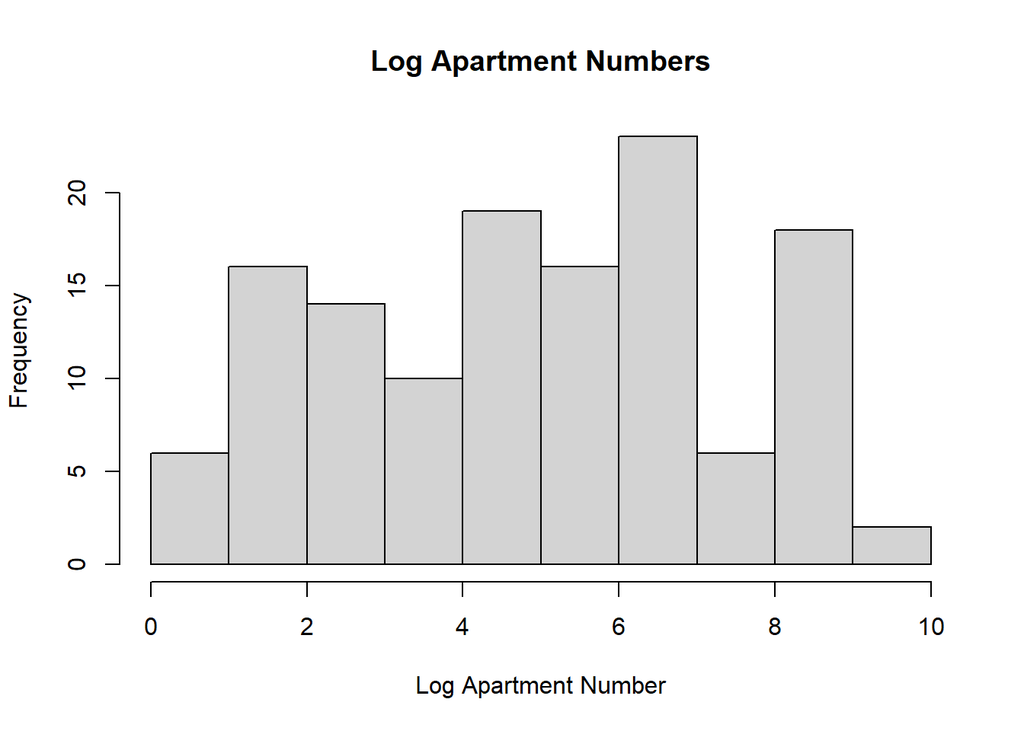

```r
numbers <- as.numeric(
  stringr::str_extract(australia$address, "\\d+$")
)

hist(
  log(numbers),
  main = "Log Apartment Numbers",
  xlab = "Log Apartment Number"
)
```

**f.**

```r
first_digit <- substr(numbers, 1, 1)

table(first_digit)
```

```
first_digit
 1  2  3  4  5  6  7  8  9
12 19 16 13 14 18  8 11 19
```

The first digits were distributed relatively evenly instead of decreasing as expected under Benford’s law. Therefore, the apartment numbers do not appear to be real data.